# Practica04: Ventas Apple

Ignacio Ruiz de Zuazu Echevarría

15/11/2020

[link a GitHub](https://github.com/ignacio-ruiz-de-zuazu/Prediccion-practicas.git)

[figure not shown]

## Librerías que se van a emplear

```r
library(readr)
library(janitor)
library(here)
```

```r
library(ggplot2)
library(magrittr)
library(skimr)
library(Hmisc)
require(forecast)
require(xts)
require(ggplot2)
```

## Dataset

Datos trimestrales delas ventas de Apple desde el 2T de 2008 hasta el 3T del 2017.

```
##   Trimestre Ingresos
## 1   Q2 2008     7980
## 2   Q3 2008     7561
## 3   Q4 2008    11520
## 4   Q1 2009    11880
## 5   Q2 2009     9084
## 6   Q3 2009     9734
```

## Análisis descriptivo

```
## [1] "Trimestre" "Ingresos"
```

Data summary

| Name | data |
| --- | --- |
| Number of rows | 38 |
| Number of columns | 2 |
| _______________________ |  |
| Column type frequency: |  |
| character | 1 |
| numeric | 1 |
| ________________________ |  |
| Group variables | None |

**Variable type: character**

| skim_variable | n_missing | complete_rate | min | max | empty | n_unique | whitespace |
| --- | --- | --- | --- | --- | --- | --- | --- |
| Trimestre | 0 | 1 | 7 | 7 | 0 | 38 | 0 |

**Variable type: numeric**

| skim_variable | n_missing | complete_rate | mean | sd | p0 | p25 | p50 | p75 | p100 | hist |
| --- | --- | --- | --- | --- | --- | --- | --- | --- | --- | --- |
| Ingresos | 0 | 1 | 36292.47 | 19632.6 | 7561 | 16860.75 | 37452 | 48916.75 | 78351 | ▇▃▇▃▂ |

```
## data
##
##  2  Variables      38  Observations
## --------------------------------------------------------------------------------
## Trimestre
##        n  missing distinct
##       38        0       38
##
## lowest : Q1 2009 Q1 2010 Q1 2011 Q1 2012 Q1 2013
## highest: Q4 2012 Q4 2013 Q4 2014 Q4 2015 Q4 2016
## --------------------------------------------------------------------------------
## Ingresos
##        n  missing distinct     Info     Mean      Gmd      .05      .10
##       38        0       38        1    36292    22518     8918    10984
##      .25      .50      .75      .90      .95
##    16861    37452    48917    57719    74708
##
## lowest :  7561  7980  9084  9734 11520, highest: 57594 58010 74599 75324 78351
## --------------------------------------------------------------------------------
```

## Modelos ETS

Primero hay que realizar una función constructora para crear un objeto de serie temporal extensible (xts) para guardar los índices del dato.

```
##             [,1]
## 2008-04-01  7980
## 2008-07-01  7561
## 2008-10-01 11520
## 2009-01-01 11880
## 2009-04-01  9084
## 2009-07-01  9734
```

### Gráfico de las ventas a través del horizonte temporal

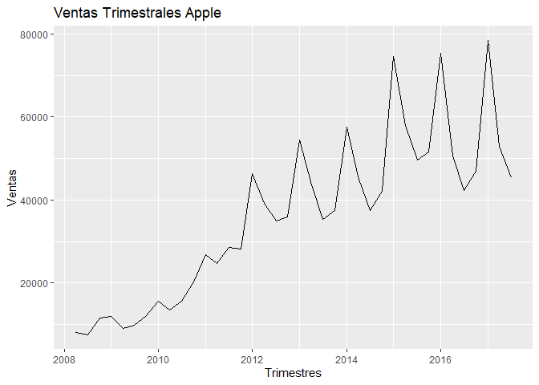

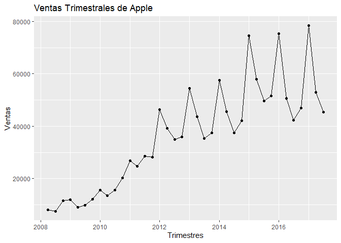

Se observa una tendencia creciente pero del mismo se aprecia que la serie no oscila entorno a una media y se obsercan picos similares entre algunos trimestres que hacen sospechar de cierta estacionalidad.

### Creación de la muestra para realizar las predicciones

```
##             [,1]
## 2008-04-01  7980
## 2008-07-01  7561
## 2008-10-01 11520
## 2009-01-01 11880
## 2009-04-01  9084
## 2009-07-01  9734
```

```
##             [,1]
## 2015-07-01 49605
## 2015-10-01 51501
## 2016-01-01 75324
## 2016-04-01 50557
## 2016-07-01 42358
## 2016-10-01 46852
```

Se realiza una muestra con el objetivo de poder realizar predicciones de las ventas de Apple mediante el empleo de modelos ETS.

### Selección del modelo ETS

El método ETS (Error, Trend, Seasonal) es un método de aproximación para pronosticar series de tiempo univariadas. Este modelo ETS se centra en los componentes de tendencia y estacionales. La flexibilidad del modelo ETS radica en su capacidad de tendencia y componentes estacionales de diferentes rasgos.

### Modelo para el forecast

```
##
## Forecast method: ETS(M,A,N)
##
## Model Information:
## ETS(M,A,N)
##
## Call:
##  ets(y = muestra_ventas)
##
##   Smoothing parameters:
##     alpha = 0.2565
##     beta  = 1e-04
##
##   Initial states:
##     l = 6413.5345
##     b = 1453.533
##
##   sigma:  0.2431
##
##      AIC     AICc      BIC
## 751.0717 753.1407 758.8485
##
## Error measures:
##                     ME     RMSE      MAE       MPE     MAPE      MASE
## Training set -233.9197 9284.965 6632.582 -5.137155 18.25842 0.8301042
##                    ACF1
## Training set 0.06283012
##
## Forecasts:
##    Point Forecast    Lo 80    Hi 80    Lo 95     Hi 95
## 36       56667.72 39009.77 74325.68 29662.22  83673.23
## 37       58120.44 39419.36 76821.52 29519.61  86721.27
## 38       59573.15 39842.53 79303.77 29397.77  89748.53
## 39       61025.87 40276.43 81775.30 29292.35  92759.38
## 40       62478.58 40718.77 84238.39 29199.83  95757.34
## 41       63931.29 41167.66 86694.93 29117.32  98745.27
## 42       65384.01 41621.54 89146.48 29042.45 101725.57
## 43       66836.72 42079.09 91594.35 28973.20 104700.25
## 44       68289.44 42539.22 94039.66 28907.88 107671.00
## 45       69742.15 43000.97 96483.34 28845.04 110639.26
```

Predicciones de 2017- 2018

### Comparación valores actuales y predicción

```
##          [,1]  [,2]
## [1,] 56667.72 78351
## [2,] 58120.44 52896
## [3,] 59573.15 45408
```

Se comparan los datos reales con los que han conseguido predecir con el modelo y vemos que existe un error significativo entre el modelo y la realidad.

### Predicciones y Precisión

```
##            ME          RMSE           MAE           MPE          MAPE
## 1631.71485476 5547.24116365 4309.06585239    0.88999690    6.69226842
##          ACF1     Theil's U
##   -0.05148699    0.19082258
```

## Modelos ARIMA

El modelo ARIMA nos premite describir un valor como una función lineal de datos anteriores y errores debidos al azar, además, puede incluir un componente estacional. Es decir, debe contener todos los elementos necesarios para describir el fenómeno.

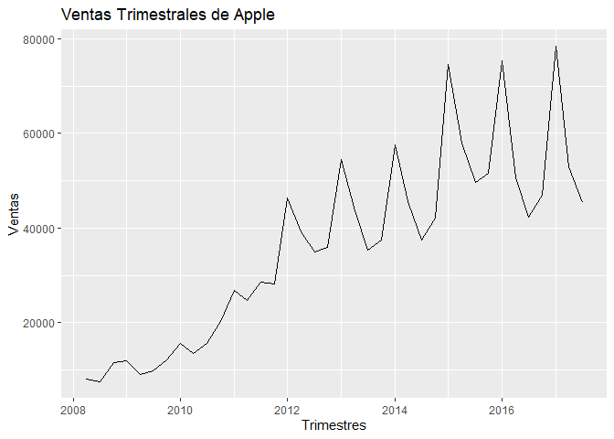

Transformarmos los ingrsos en logaritmo para que la serie se vuelva más estacionaria.

### Diferencias

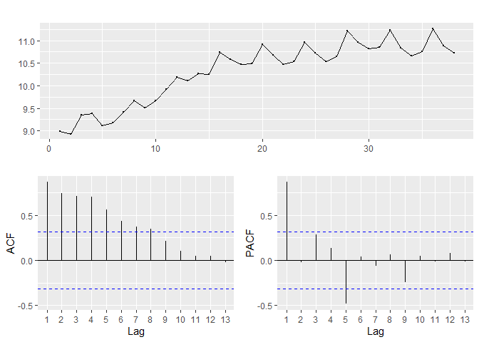

Las líneas azules hacen contraste de hipótesis para ver si hay correlación o no. Si están dentro de las bandas es estadísticamente igual a 0, si están fuera estadísticamente hay una correlación. No estacionario es algo de hace mucho tiempo que sigue explicando lo de hoy en el acf como ocurren en este caso, por lo que esta serie es no estacionaria.

Se observa que las ventas de un día dependen del día anterior y éste del día anterior como se ve en el ACF. Por ello se le aplica una diferencia regular. Ahora las ventas oscilan entorno a una media.

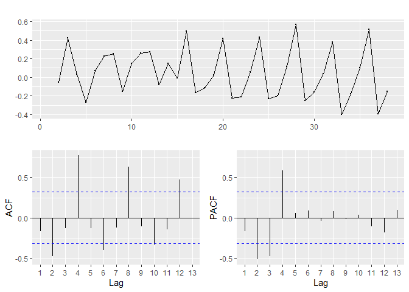

Se aprecia una estacionalidad cada 4 trimestres, o lo que es lo mismo, cada año en el mismo trimestre se aprecia una misma tendencia.

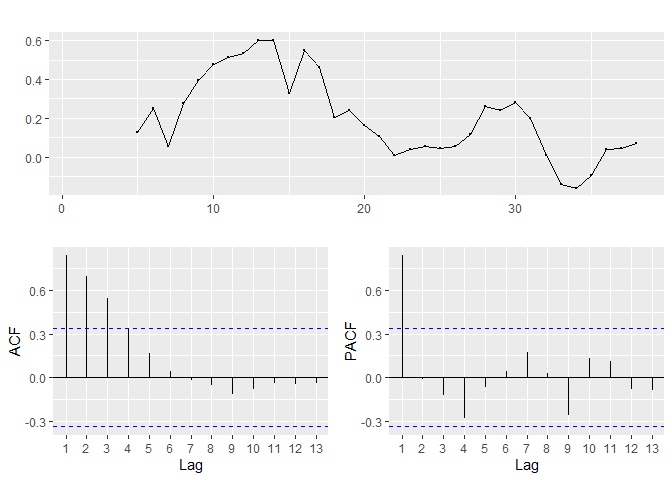

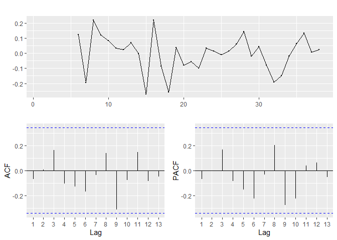

### Realización del modelo ARIMA

```r
modelo_arima <- auto.arima(muestra_ventas, lambda = 0)
summary(modelo_arima)
```

```
## Series: muestra_ventas
## ARIMA(0,1,1) with drift
## Box Cox transformation: lambda= 0
##
## Coefficients:
##           ma1   drift
##       -0.5132  0.0538
## s.e.   0.1483  0.0200
##
## sigma^2 estimated as 0.05678:  log likelihood=1.4
## AIC=3.2   AICc=4   BIC=7.78
##
## Training set error measures:
##                     ME     RMSE      MAE       MPE     MAPE      MASE
## Training set -688.9061 10108.51 7351.879 -2.379804 19.01593 0.9201283
##                    ACF1
## Training set 0.02240556
```

# Análisis de los residuos

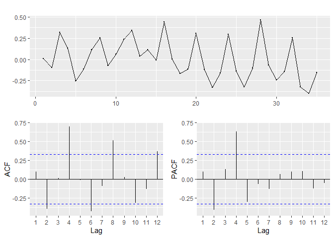

```r
ggtsdisplay(modelo_arima$residuals)
```

# Predicción ARIMA

```
##
## Forecast method: ARIMA(0,1,1) with drift
##
## Model Information:
## Series: muestra_ventas
## ARIMA(0,1,1) with drift
## Box Cox transformation: lambda= 0
##
## Coefficients:
##           ma1   drift
##       -0.5132  0.0538
## s.e.   0.1483  0.0200
##
## sigma^2 estimated as 0.05678:  log likelihood=1.4
## AIC=3.2   AICc=4   BIC=7.78
##
## Error measures:
##                     ME     RMSE      MAE       MPE     MAPE      MASE
## Training set -688.9061 10108.51 7351.879 -2.379804 19.01593 0.9201283
##                    ACF1
## Training set 0.02240556
##
## Forecasts:
##    Point Forecast    Lo 80     Hi 80    Lo 95     Hi 95
## 36       53570.36 39472.99  72702.46 33580.94  85458.71
## 37       56531.19 40251.84  79394.53 33628.13  95032.83
## 38       59655.67 41175.64  86429.72 33838.11 105171.34
## 39       62952.84 42222.49  93861.36 34175.40 115962.37
## 40       66432.25 43379.47 101735.76 34617.92 127484.35
## 41       70103.96 44638.80 110096.24 35151.23 139812.02
## 42       73978.60 45995.94 118985.15 35765.56 153019.67
## 43       78067.40 47448.43 128445.11 36454.16 167183.07
## 44       82382.18 48995.33 138519.82 37212.40 182380.74
## 45       86935.45 50636.79 149254.58 38037.08 198694.86
```

Se observan las predicciones del modelo ARIMA de los años 2017 y 2018.

# Comparación valores actuales y predicción

```r
matrix(c(forecast_modelo_arima$mean[1:omision_muestra],
         xventas[(total_observaciones - omision_muestra + 1):total_observaciones]),
       ncol = 2)
```

```
##          [,1]  [,2]
## [1,] 53570.36 78351
## [2,] 56531.19 52896
## [3,] 59655.67 45408
```

Se comparan los datos reales con los que han conseguido predecir con el modelo y vemos que existe un error significativo entre el modelo y la realidad como ocurría anteriormente con los modelos ETS.